# Can mandatory jail law reduce the fatality

Team Id:11

Xi Yang (Introduction, Analysis plan, Comparison)

Shan Gao (Model fitting,F-test,Causal Statement)

Yuxiang Lin (Descriptive Analysis and Conclusion)

Ziyi Zhou (Model Diagnositic, Report)

Github Repo: https://github.com/zhouzyzyzyzy/STAT207.git

# 1. Introduction

## 1.1 Background

The global epidemic of road crash fatalities and disabilities is gradually being recognized as a major public health concern. There are approximately 40,000 highway traffic fatalities each year in the United States and an additional 2.35 million are injured or disabled, leading to the road safety a shared responsibility. In this report, we aim to study the influential factors for traffic fatalities and offer policymakers feasible suggestions in reducing fatalities.

The dataset “Fatalities” contains the traffic fatalities data for 48 U.S. states(excluding Alaska and Hawaii) from 1982 to 1988. We are interested in alcohol factors, social economical conditions and legal terms associated with vehicle crashes. Based on the literature review and dataset information, we will use fixed effect model with selected factors to study whether having a mandatory jail sentence is associated with reduced traffic fatalities.

# 2. Analysis Plan

## 2.1 Model selection

In our particular case, we are looking to observe the effects of a series of variables, based on which, we want to make suggestions to policymakers to take certain measures. We sampled all the states across the U.S. We also hope that our model would improve the national highway traffic safety within the U.S. In this case, the target population is the same with sample population. We are interested in making conclusions about whether jail sentences and other factors impact the fatality rate, then the variables would be fitted as fixed effects. The data set we used in this report is a panel data so we choose the fixed effect regression to build our model.

## 2.2 Descriptive Analysis

The original dataset has 336 observations obtained from 48 U.S. states and 7 consecutive years from 1982 to 1988. We conduct a both-direction stepwise regression to check which variables are significant enough to be involved in the model. Based on the result, we select variables state, year, jail sentence, unemployment rate, spirits consumptions, income, beer tax, average miles per driver and baptist to build out model.

## 2.2.1 Overview of the whole dataset

We first take look at the continuous variables involved in the dataset.

```
                                 Figure 1
```

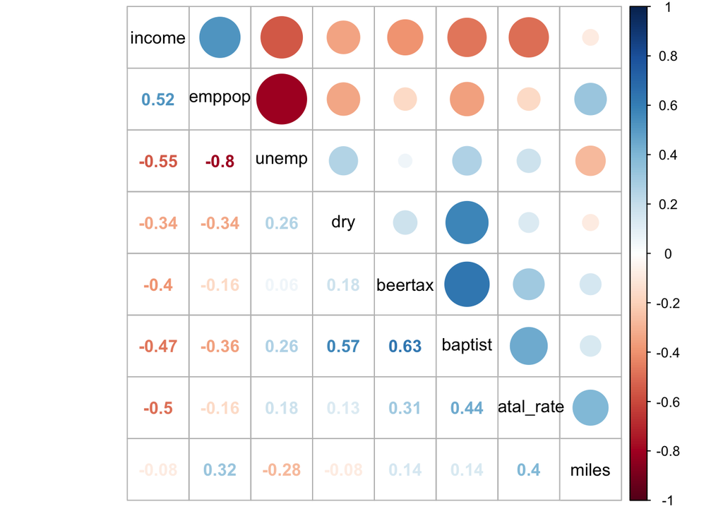

The correlation matrix `Figure 1` shows the correlations between continuous variables from the ‘Fatalities’ dataset. The blue color represents the positive relation and red color represents the negative relation. The darker color indicates the higher value of the absolute correlation. From the correlation matrix plot, we can find multicollinearity issue especially in income with other variables. In addition, there is a high positive correlation between beer tax and baptist percentage(0.63) and a high negative correlation between employee and unemployee rate(-0.8).

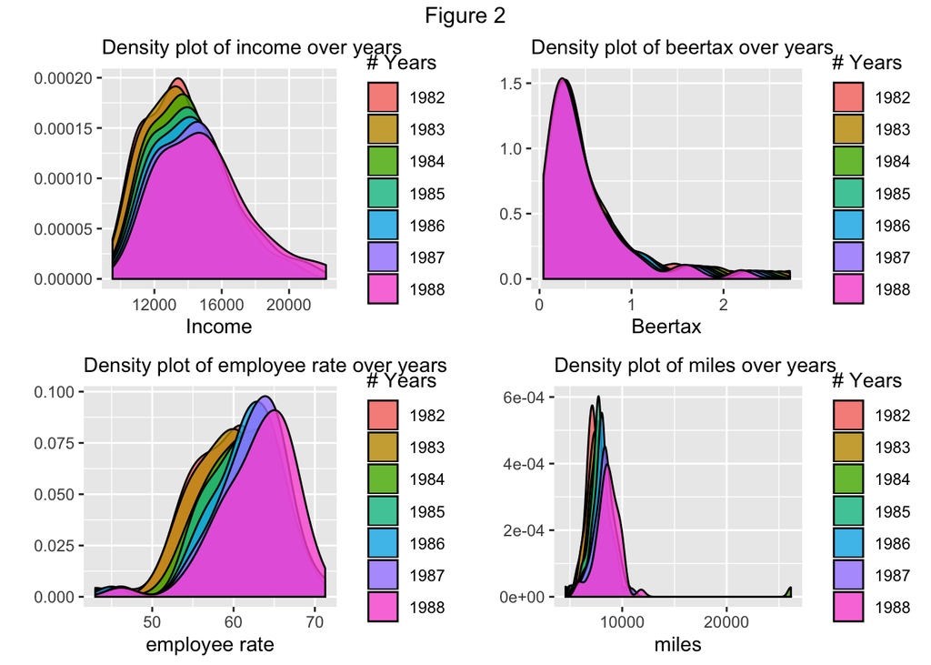

`Figure 2` shows the density plot for income, beer tax, employee rate and driving miles. We can see the density plot is asymmetric and have trend over time. There are increasing trends in income, employee rate and driving miles since the density moves to the right side of the coordinate. What’s more, Beer tax tends to drop over time.

## 2.2.2 Fatalities and its indicators

We summarize three informative aspects associated with the traffic fatal rate below:

- $\textbf{Alcohol factors:}$ Alcohol drinking is connected with drunk driving and almost half of drivers and more than 40% of passengers killed in vehicle crashes have been drinking `[1]`. Beer tax, spirits consumption and percentage of Baptist are indicators of alcohol consumption within a state. Beer tax and spirits consumption directly influences the beer purchase and Baptist(Southern Baptist holds a general rule of having opposed drinking alcoholic beverages). By exploring the data we find a high positive relations between Beer tax, Baptist percentage and fatal rate as well as a negative relations between spirits consumption and fatal rate `Figure 3`, indicating the necessity of considering these three factors in our model.

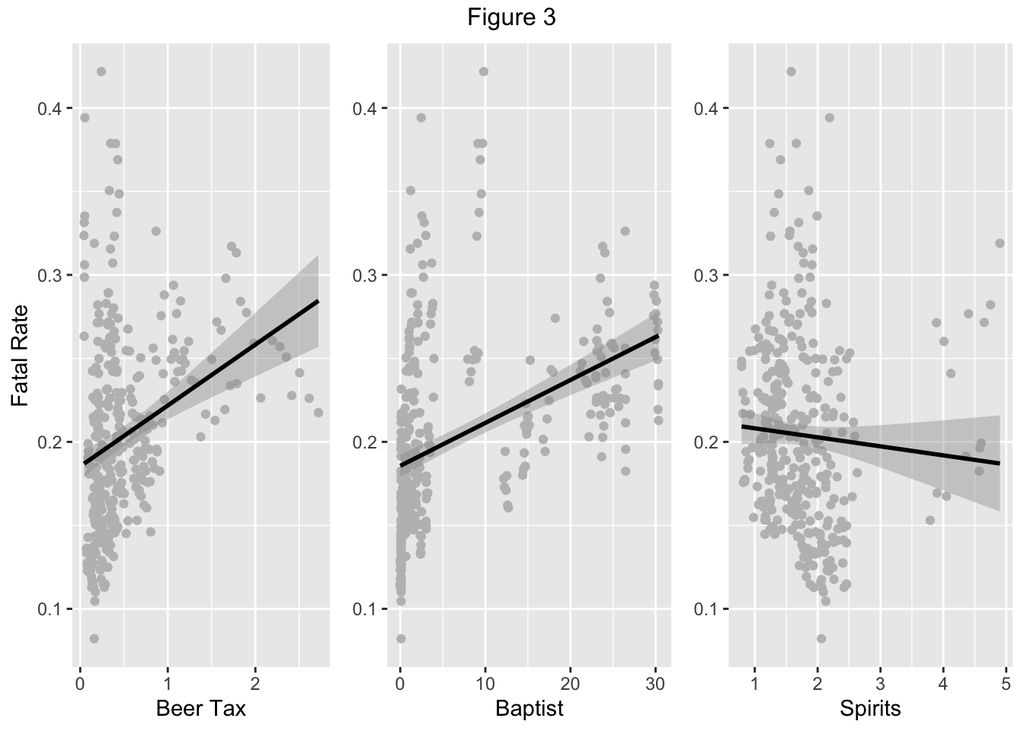

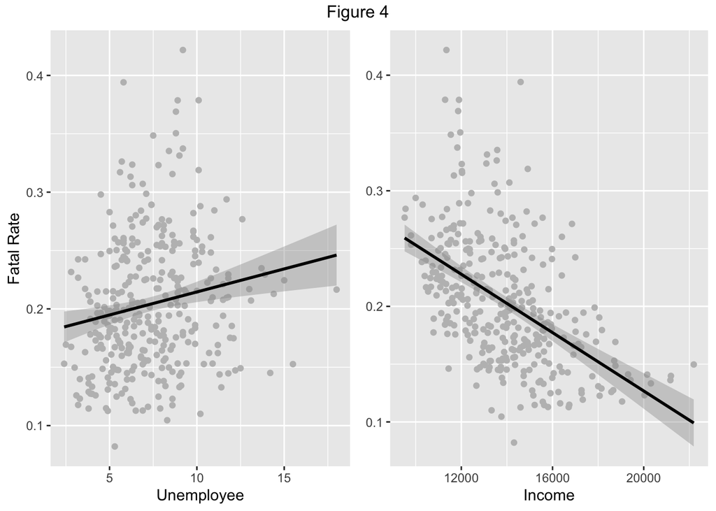

- $\textbf{Legal terms:}$ Time served in jail is considered as a proper punishment for drunk driving and currently in all states, first-offense driving under the influence(DUI) is classified as a misdemeanor, and punishable by up to six months in jail. Despite the brevity of substituting community service, these laws have been strongly supported as providing the severity necessary for effective deterrence of drunk driving `[3]`. The grouped boxplots `Figure 5` show there might exist the treatment effect under different legal penalties towards drunk driving. In addition, the preliminary breath test law affects the procedure of determining drunk driving cases and there might exist treatment effects as well.

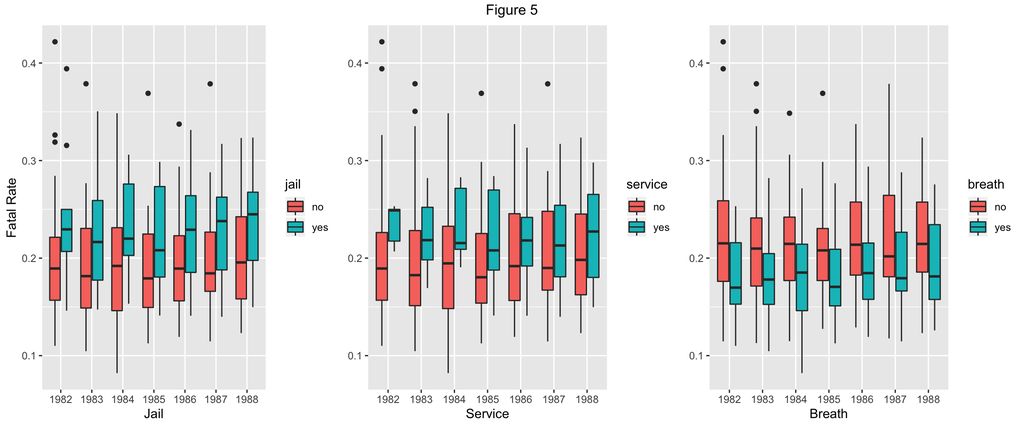

The traffic fatalities are associated with other factors including those unobserved in our dataset. As we see from the upper panel of `Figure 6`, fatal rate within some states vary to some extent, it might result from the changing policy(Connecticut state revised the law of mandatory jail in 1985) as well as the unobserved variables fluctuate over time. In addition, the lower panel shows the map plot for fatalities rate among the United States in 1982. The darker block represents the lower fatal rate and it indicates that fatal rates vary among states.

To eliminate the source of omitted variable bias, we need to consider sources vary across states but are constant over time(e.g. In-state public attitude towards drinking) and sources vary over time but are constant across state(e.g. Manufacturing skills in car industry)

We incorporate these two factors as the fixed effects in our model to control for unobserved variables and estimation bias.

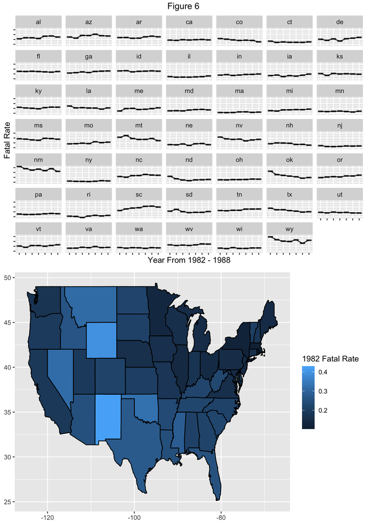

## 2.3 Fixed effect Model

The `fixed effects regression model`[4] is:
$$Y_{it} = \gamma X_{it}+\eta Z_{it}+\alpha_i+\beta_{t}+\epsilon_{it}$$
$\textbf{Explanation of the notation}$

- The index $i$ denotes factor level of state and the index $t$ denotes factor level of year.
- $Y_{it}$ denotes the observed outcome of the fatality rate in the $i$th state and $t$th year, $X_{it}$ denotes the jail variable in the $i$th state and $t$th year, $Z_{it}$ vector denotes the other observed variables in the $i$th state and $t$th year.
- $\gamma$ and $\eta$ vector denotes the coefficient of jail and other interst variables.
- The $\alpha_i$ and $\beta_t$ are entity-specific intercepts that capture heterogeneities across entities and time.
- $\epsilon_{it}$ denotes random errors. These are unobserved random variables.

$\textbf{Assumption}$: The model errors are assumed to be identically and independently distributed from a normal distribution with zero mean and equal variance.

# 3. Results and Discussian

## 3.1 Fixed Effect Model

To do the hypothesis test, we should specify the test rules of fixed effect model here:
$$H_{0j}: \beta_j = 0, j = 1,2,...,p \;v.s\;H_{1j}: \beta_j \neq 0, j = 1,2,...,p$$

and use F statistic to do the test. Table1 shows our model fitting result:

[output not shown]

Table 1: Model Result

[output not shown]

Table 2: Confidence interval

Table 2 shows the confidence interval. The estimator of Spirit consumption suggests that there is a positive correlation between traffic fatalities rate and alcohol consumption per capita. The result shows that per liter increase in alcohol consumption, the fatality rate increases 0.08 units, significant (P<0.05). When the consumption of alcohol goes up, we assume that the proportion of drunk drivers will also increase and, accordingly, the fatality will rise.

The income per capita has a positive correlation with the response variable. The unemployment rate has an inverse correlation with the response variable. Both are significant (P<0.05). The jail is not significant and has a positive correlation with the fatalities rate. The estimator of the beer tax has a negative correlation with the fatalities rate. The sign of beer tax indicates that higher the beer tax is, lower the consumption of alcohol is, and lower the fatalities rate is. However, the beer tax is not significant (P>0.05). The estimator of baptist and service are not significant at the 0.05 level.

## 3.2 Model Diagnostics

Based on those results, we can conclude that the robustness and reliability of this model need to improvement, and the reliability of conclusion above is not strong. We need to improve our model. In this case, even though jail is not significant (P>0.05), we still want to do causal inference to make sure whether it is the causal effect of the fatality rate.

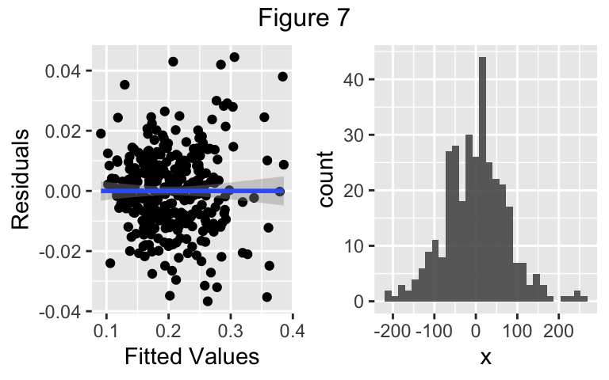

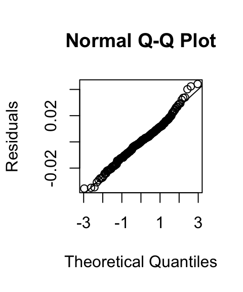

## 3.3 Causal Inference

This experiment is designed as an observational study. The experiment units were not randomly generated nor independent with each other. Propensity score matching is a powerful technology that allows for causal inference in this type of case. In the empirical example, we adjusted for confounding using nearest neighbor matching.

Figure 8

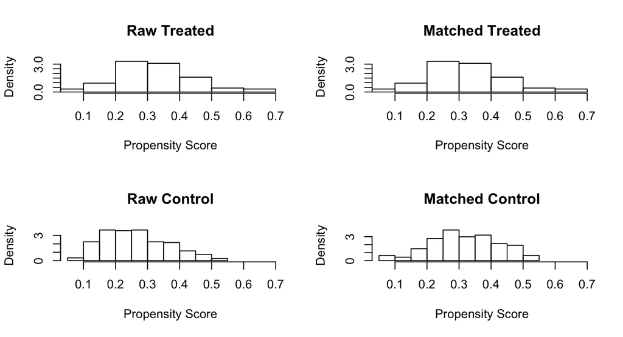

| Sample Sizes | Control | Treated |
| --- | --- | --- |
| All | 241 | 94 |
| Matched | 94 | 94 |
| Unmatched | 147 | 0 |
| Discarded | 0 | 0 |

Table 3: Sample sizes

- Estimate the Propensity Score-Adjusted Treatment Effects  
  Finally, we use the Zelig function to create the model to evaluate the impact of being sentenced in a jail with the matched data. We can see that the jail variable is significant under 5% significance level. Hence, a causal statement can be made that the estimates of the causal effect suggest that jail sentence is expected to produce a higher fatality rate.

# 4. Conclusion and Suggestion

Using a large panel data of traffic fatalities with 48 states in the U.S. in 7 consecutive years, from 1982 to 1988, we investigate whether the drinking factor, the economic factor and the legal factor influence the fatality rate with fixed effect model and whether the mandatory jail law is the cause of fatality rate. Based on the result, we find that economic factors (income and unemployment) and Spirit consumption are associated with the fatality rate. We also do the causal inference and find that mandatory jail law is the causal effect of the fatality rate. The coefficient of mandatory jail law is positive, Therefore, we can make suggestions to policymakers that cancel the mandatory jail law and pay more attention to other factors lik e road infrastructure and economic development.

# 5. Further study

In our previous study, we are interested in whether mandatory jail law can reduce the traffic fatality. We are also interested in some other economic, demographic, geographic and regulatory factors and their effect on the traffic fatality. Based on the references, we reselect the variables we are interested in, including beertax, baptist, Spirits consumption, miles, breath law, jail law, drink age law, service punishment, unemployment rate, income, dry residence rate and GSP change of rate. We use Fixed-effects FGLS regression to estimate our model.

## 5.1 literature review and variables selection

On the basis of our previous study, we conducted more literature reading and find that In pavel and Margaret’s study, even though the climate is outside of policy maker;s control, their estimates suggest that climate plays a very important role in traffic fatalities. So we add dry residence rate as a climate factor. We add drink age as one factor related to alcohol law and also add GSP rate as a economic factor.

## 5.2 Feasible General Least Square(FGLS) regression

Our panel data shows significant state fixed effect. In our previous study we find that the equal variance assumption of OLS does not hold, and there is some degree of correlation between the residuals in the regression model. In this case, the OLS can be statistically inefficient and may mislead the inference result. To solve this problem, we use the FGLS estimate.

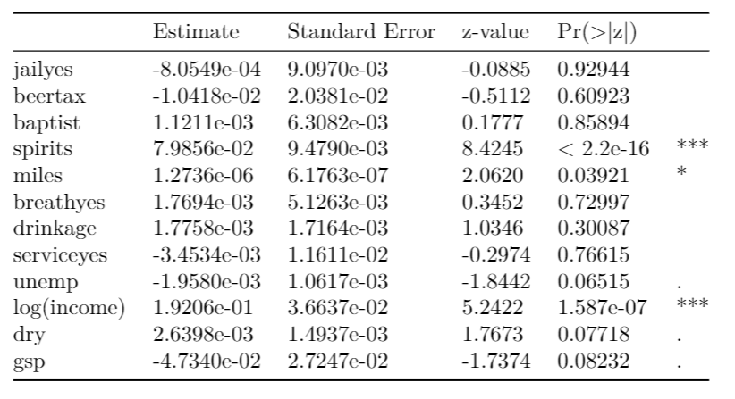

Table 4: The determinants of the Traffic Fatality rate  
The parameter estimates for the variables are shown in `table 4`. We can see that the consumption of Spirits, miles, and logarithmic income are significant at significant level 0.05; unemployment rate, dry residence rate and GSP rate of change are significant at significant level 0.1.

## 5.3 Instumental Variables Regression

According to the model above, we notice that the correlations between the residual and variables cannot be ignored.

Table 5: Correlations between the residual and variables

| Correlation | Spirit | income | miles | dry | gsp |
| --- | --- | --- | --- | --- | --- |
| Residuals | 0.011 | -0.004 | 0.001 | -0.001 | 0.004 |

We know that regression models may suffer from problems like omitted variables and measurement errors, which means the error term is correlated with the variables in the model. It may make the estimator inconsistent for the true value. In our model, the correlations of all the significant variables and residuals are shown in table 5. We may consider all of them except spirit as zero since they are small enough. It is necessary to find instrumental variables for spirit term.

Instrumental variables (IV) regression is a general technique for obtaining a consistent estimator[8]. Assume there is a simple regression model:
$$Y_i =\beta_0+\beta_1X_i+\epsilon_i,\quad i=1,2,...,n$$
where $\epsilon_i$ is correlated with $X_i$. A single instrumental variable $Z$ is used to obtain a consistent estimator for $\beta_1$.

Hence, a valid instrumental variable must satisfy two conditions:

- Instrument relevance condition: $\rho(Z,X)\neq0$
- Instrumant exogeneity condition: $\rho(Z,\epsilon)=0$

One of IV regression tool called two-stage least squares (TSLS), which is what we use here.

### The Two-Stage Least Squares Estimator

The first stage regression model is
$$X_i=\pi_0+\pi_1 Z_i+\nu_i,$$
In the first stage, the variation in $X$ is decomposed into a problem-free component that is explained by the instrument $Z$ and a problematic component that is correlated with the error $\epsilon$. Here, $\hat{X_i} = \pi_0+\pi_1 Z_i$ is the component of $X_i$ which is explained by $Z_i$ while $\nu_i$ is the component that cannot be explained by $Z_i$ and exhibits correlation with $\epsilon$.

The second stage is:
$$Y_i =\beta_0+\beta_1\hat{X_i}+\epsilon_i,\quad i=1,2,...,n$$
The second stage produces $\hat{\beta_0}^{TSLS}$ and $\hat{\beta_1}^{TSLS}$, the TSLS estimator of $\beta_0$ and $\beta_1$. Actually, the TSLS estimator of $\beta_1$ is:
$$\hat{\beta_1}^{TSLS}=\frac{S_{ZY}}{S_{ZX}}$$
### Result of Instrumental variable We test all other variables in the dataset. The result is shown in `Table 6`

Table 6: Correlation of each variable

| Correlation | Spirit | Residuals |
| --- | --- | --- |
| Population | -0.065 | 0.000 |
| Baptist | 0.294 | 0.000 |
| Beertax | -0.089 | -0.015 |
| drinkage | -0.084 | 0.027 |
| mormon | -0.018 | 0.001 |
| youngdrivers | -0.059 | 0.017 |

Obviously, baptist and population are the best choice since they are correlated with the spirit and uncorrelated with the residuals. Then, we perform three different instrumental variable estimations for our model using “ivreg()” function: instrument is only baptist, only population and both of them.

The coefficients on spirit are shown in the `Table 7`:

Table 7: coefficients of the model on spirit

| Coefficient | pop | baptist | pop and baptist |
| --- | --- | --- | --- |
| spirits | 0.028 | -0.238 | 0.022 |

The coefficients on spirit are quite different in magnitude. Which one should we trust? We compute F-statistics for the first-stage regressions of all three models to check instrument relevance.

For the third model, we obtain a chi-squared distributed test statistic instead of an F-statistic, because the coefficient is overidentified. Here, for a general instrumantal variables regression model. If the number of instrumantal variables are larger than the number of endogenous regressors, the coefficients are overidentified.

Table8: Test of the model

| Coefficient | pop | baptist | pop and baptist |
| --- | --- | --- | --- |
| P-value | 3.26e-06 | 0.01896 | 1.29e-08 |

For the third model, the value is smaller than 0.05, we reject the hypothesis that both instruments are exogenous at the level of 5%. This means one of the following:

1. The pop is an invalid instrument
2. The baptist rate is an invalid instrument
3. Both instruments are invalid

Finally, we conclude that the pop variable can be consider as the valid instrumental variable in this case and the most trustworthy estimate is 0.028. The interpretation of this estimate is that an increase in the spirit consumption is expected to increase the fatality rate by about 0.028 percentage points.

## 5.4 Policy suggestion

### 5.4.1 Strong enforcement

According to the Congressional Research Service (2019), it will have a significant impact initially but will evoke resistance later. There is a fact that almost half the states changed their laws to comply with the federal requirements within the first three years. But in the succeeding 13 years, almost none of the remaining states have changed their laws to comply with the requirements. It may indicate that strong enforcement is not that effective in reducing fatality rate, so most of the states did not take similar measures. Combined with the result in our model, we do not recommend setting a jail to reduce the fatality rate. Education or incentives may be a better way.

### 5.4.2 Economics

Periods of economic recession are associated with declines in traffic crashes, injuries, and deaths. Income is directly proportional to the number of traffic deaths. As income decreases, the consumption of common commodities will decrease. As the price of gasoline rises, there will be less driving, which will reduce traffic fatality. So, to reduce the traffic fatality rate, our suggestion is to raise oil prices properly.

### 5.4.3 Alcohol

Alcohol is the largest contributing factor in fatal vehicle crashes. Logically, there is a strong connection between drinking and traffic fatalities, so as alcohol consumption increases one can assume the rate of intoxicated drivers also increase. To raise the alcohol price and limit the number of purchases may be a good way.

### 5.4.4 Technologies

A federal study estimated that half of the improvement in highway fatality rates between 1960 and 2012 was attributable to improvements in vehicle safety technologies. Most of the vehicle safety technologies analyzed in the study increased the likelihood that vehicle occupants would survive a crash. More recently, technological improvement has focused on preventing crashes. While some crash-prevention technologies, such as automatic braking and lane departure warnings, are available now. Funding more on technologies improvement is not only good for national development but also reduction in fatality rate. The impact of road maintenance investment on total fatalities is statistically significant among Spain cities.[6] The sign of this coefficient in this report indicates that spending in maintenance is effective in reducing both fatalities and casualties. Hence, we believe that we can learn from Spain to invest more on the road infrastructure and reduce fatality rate.

# Reference

[1]. Ruhm, Christopher J. “Alcohol policies and highway vehicle fatalities.” Journal of health economics 15.4 (1996): 435-454.  
[2]. https://www.sciencedaily.com/releases/2016/01/160121132534.htm  
[3]. https://scholarlycommons.law.northwestern.edu/cgi/viewcontent.cgi?article=6657&context=jclc  
[4]. https://www.econometrics-with-r.org/rwpd.html#drunk-driving-laws-and-traffic-deaths  
[5]. https://www.ncbi.nlm.nih.gov/pmc/articles/PMC4098642/  
[6]. http://www.ub.edu/gim/wp-content/uploads/2013/10/Albalate-Fernandez-Yarygina-2013.pdf  
[7]. https://crsreports.congress.gov/product/pdf/R/R44394  
[8]. https://www.econometrics-with-r.org/12-ivr.html  
[9]. Pavel A. Yakovlev & Margaret Inden, 2010. “Mind the Weather: A Panel Data Analysis of Time-Invariant Factors and Traffic Fatalities,” Economics Bulletin, AccessEcon, vol. 30(4), pages 2685-2696.

# Appendix

```
##
## Call:
## matchit(formula = jail ~ spirits + unemp + income + baptist,
##     data = mydata, method = "nearest", ratio = 1)
##
## Summary of balance for all data:
##          Means Treated Means Control SD Control Mean Diff  eQQ Med
## distance        0.3266        0.2626     0.0997    0.0640   0.0674
## spirits         1.7004        1.7746     0.6386   -0.0742   0.1100
## unemp           7.9383        7.1245     2.4144    0.8138   0.7000
## income      13326.7360    14078.7541  2229.7252 -752.0180 945.8691
## baptist         5.8978        7.6703    10.2243   -1.7724   0.6894
##          eQQ Mean   eQQ Max
## distance   0.0659    0.1704
## spirits    0.1780    1.4900
## unemp      0.8223    2.5000
## income   902.4125 1770.9473
## baptist    2.4076   13.7640
##
##
## Summary of balance for matched data:
##          Means Treated Means Control SD Control Mean Diff  eQQ Med
## distance        0.3266        0.3179     0.1051    0.0088   0.0010
## spirits         1.7004        1.7509     0.6741   -0.0504   0.0800
## unemp           7.9383        7.5702     2.6219    0.3681   0.3000
## income      13326.7360    13481.5622  2156.8600 -154.8262 223.6265
## baptist         5.8978        5.2934     8.8158    0.6045   0.9407
##          eQQ Mean   eQQ Max
## distance   0.0098    0.1704
## spirits    0.1464    1.4900
## unemp      0.3766    2.5000
## income   265.8856 1025.0234
## baptist    1.3373    5.3209
##
## Percent Balance Improvement:
##          Mean Diff.  eQQ Med eQQ Mean eQQ Max
## distance    86.2887  98.5103  85.1634  0.0000
## spirits     32.0230  27.2727  17.7525  0.0000
## unemp       54.7705  57.1428  54.2044  0.0000
## income      79.4119  76.3576  70.5361 42.1200
## baptist     65.8971 -36.4563  44.4527 61.3419
##
## Sample sizes:
##           Control Treated
## All           241      94
## Matched        94      94
## Unmatched     147       0
## Discarded       0       0
```

[output not shown]

```
## Model:
##
## Call:
## z5$zelig(formula = fatal_rate ~ jail + spirits + unemp + income +
##     baptist, data = m.outCSV)
##
## Residuals:
##       Min        1Q    Median        3Q       Max
## -0.112114 -0.031832 -0.003939  0.019534  0.200535
##
## Coefficients:
##               Estimate Std. Error t value Pr(>|t|)
## (Intercept)  3.611e-01  3.260e-02  11.076  < 2e-16
## jail         3.313e-02  6.731e-03   4.922 1.91e-06
## spirits      2.579e-02  5.012e-03   5.146 6.86e-07
## unemp       -4.103e-03  1.432e-03  -2.865 0.004661
## income      -1.386e-05  2.004e-06  -6.917 7.58e-11
## baptist      1.473e-03  4.247e-04   3.467 0.000656
##
## Residual standard error: 0.04601 on 182 degrees of freedom
## Multiple R-squared:  0.3833, Adjusted R-squared:  0.3663
## F-statistic: 22.62 on 5 and 182 DF,  p-value: < 2.2e-16
##
## Next step: Use 'setx' method
```

```
## Twoways effects Within Model
##
## Call:
## plm(formula = fatal_rate ~ jail + state + year + unemp + log(income) +
##     beertax + +baptist + spirits + service + miles + breath,
##     data = Fatalities, effect = "twoways", model = "within",
##     index = c("state", "year"))
##
## Unbalanced Panel: n = 48, T = 6-7, N = 335
##
## Residuals:
##        Min.     1st Qu.      Median     3rd Qu.        Max.
## -0.03559012 -0.00819242  0.00021492  0.00742848  0.04416078
##
## Coefficients:
##                Estimate  Std. Error t-value  Pr(>|t|)
## jailyes      4.3060e-03  1.1083e-02  0.3885   0.69794
## unemp       -4.5451e-03  1.0868e-03 -4.1820 3.900e-05 ***
## log(income)  1.8083e-01  3.4039e-02  5.3125 2.253e-07 ***
## beertax     -3.2026e-02  1.6636e-02 -1.9251   0.05526 .
## baptist     -3.4215e-03  4.8616e-03 -0.7038   0.48216
## spirits      7.8459e-02  1.1091e-02  7.0739 1.276e-11 ***
## serviceyes  -6.6688e-04  1.2707e-02 -0.0525   0.95818
## miles        1.1867e-06  8.0732e-07  1.4699   0.14275
## breathyes    2.7845e-03  4.4411e-03  0.6270   0.53120
## ---
## Signif. codes:  0 '***' 0.001 '**' 0.01 '*' 0.05 '.' 0.1 ' ' 1
##
## Total Sum of Squares:    0.10289
## Residual Sum of Squares: 0.055716
## R-Squared:      0.45851
## Adj. R-Squared: 0.33508
## F-statistic: 25.5905 on 9 and 272 DF, p-value: < 2.22e-16
```